# Challenge infections - Descreptive statistics

#### Challenge infections with *Eimeria*. Here I am presenting some summary statistics on the laboratory infection of mice with different *Eimeria* strains.

Here is a data frame containing all information derived from the experimental infections with *Eimeria*.

```r
#### Read the file
CI <- read.csv("https://raw.githubusercontent.com/derele/Eimeria_Lab/master/data_products/Challenge_infections.csv")
```

### Wrangling

```
## # A tibble: 2,984 x 98
##    EH_ID experiment primary_infecti~ challenge_infec~ mouse_strain labels weight
##    <chr> <chr>      <chr>            <chr>            <chr>        <chr>   <dbl>
##  1 LM02~ E57        E88              E64              BUSNA_STRA   E57aA~   22.2
##  2 LM02~ E57        E88              E64              BUSNA_STRA   E57aB~   19.1
##  3 LM02~ E57        E88              E64              BUSNA_STRA   E57bx~   22.9
##  4 LM02~ E57        E88              E64              BUSNA_STRA   E57aP~   22
##  5 LM02~ E57        E88              E64              BUSNA_STRA   E57aF~   20.0
##  6 LM02~ E57        E88              E64              BUSNA_STRA   E57aN~   22.1
##  7 LM02~ E57        E88              E64              BUSNA_STRA   E57bx~   22.9
##  8 LM02~ E57        E88              E64              BUSNA_STRA   E57bx~   23.2
##  9 LM02~ E57        E88              E64              BUSNA_STRA   E57bx~   23.1
## 10 LM02~ E57        E88              E64              BUSNA_STRA   E57aG~   21.0
## # ... with 2,974 more rows, and 91 more variables: weight_dpi0 <dbl>,
## #   relative_weight <dbl>, feces_weight <dbl>, dpi <int>, infection <chr>,
## #   oocyst_sq1 <int>, oocyst_sq2 <int>, oocyst_sq3 <int>, oocyst_sq4 <int>,
## #   dilution <dbl>, OO4sq <int>, OOC <dbl>, infection_history <chr>,
## #   Eim_MC <lgl>, delta <dbl>, IFNy_CEWE <dbl>, IFNy_MES <dbl>, CXCR3 <dbl>,
## #   IRG6 <dbl>, IL.12 <dbl>, CASP1 <dbl>, CXCL9 <dbl>, CXCR3_bio <dbl>,
## #   IDO1 <dbl>, IFNy <dbl>, IL.10 <dbl>, IL.12A <dbl>, IL1RN <dbl>, ...
```

Let’s add a column with the parasite names

# Let’s add a column with the heterologous and homologous infections

```r
CI <- CI %>%
  dplyr::mutate(infection_type = case_when(
    infection_history == "E88_E64" ~ "heterologous_ferrisi",
    infection_history == "E88_UNI" ~ "falciformis_UNI",
    infection_history == "E64_E64" ~ "homologous_ferrisi",
    infection_history == "E64_UNI" ~ "ferrisi_UNI",
    infection_history == "Eflab_E88" ~ "homologous_falciformis",
    infection_history == "Eflab_E64" ~ "heterologous_ferrisi",
    infection_history == "Eflab_UNI" ~ "falciformis_UNI",
    infection_history == "E64_E88" ~ "heterologous_falciformis",
    infection_history == "E139_E88" ~ "homologous_falciformis",
    infection_history == "E139_E64" ~ "heterolous_ferrisi",
    infection_history == "E139_UNI" ~ "falciformis_UNI",
    infection_history == "UNI_E88" ~ "UNI_falciformis",
    infection_history == "UNI_E64" ~ "UNI_ferrisi",
    infection_history == "UNI_UNI" ~ "UNI",
    infection_history == "E88_E88" ~ "homologous_falciformis",
    TRUE ~ ""))
```

### Summary statistics on experimental design

#### Summarizing data by each mouse

#### How many mice do we have in each infection ? (primary or challenge infection)

```
## # A tibble: 2 x 2
##   infection total_mice
##   <chr>          <int>
## 1 challenge        132
## 2 primary          153
```

#### How many experiments do we have? How many mice are in each experiment?

```
## # A tibble: 5 x 2
##   experiment total_mice
##   <chr>           <int>
## 1 E10                52
## 2 E11                55
## 3 E57               106
## 4 P3                 32
## 5 P4                 40
```

#### How many mouse strains do we have?

We here use four wild-derived inbred mouse strains. from these mouse strains F1 hybrids were generated.

Two parental strains represented M. m. domesticus: - SCHUNT (Locality: Schweben, Hessen, Germany [N: 5°0 26′, E: 9°36′] (Martincová et al., 2019))  
- STRA (Locality: Straas, Bavaria, Germany [N: 50°11′, E: 11°46′] (Piálek et al., 2008), Two parental strains represented M. m. musculus: - BUSNA (Locality: Buškovice, Bohemia, Czech Republic [N: 5°0 14′, E: 1°3 22′] (Piálek et al., 2008)) - PWD (Locality: Kunratice, Bohemia, Czech Republic [N: 5°0 01′, E: 14 2°9′] (Gregorová & Forejt, 2000))

```
## # A tibble: 13 x 3
## # Groups:   mouse_strain [13]
##    mouse_strain  hybrid_status       total_mice
##    <chr>         <chr>                    <int>
##  1 BUSNA_BUSNA   F0 M. m. musculus            8
##  2 BUSNA_PWD     F1 M. m. musculus            6
##  3 BUSNA_STRA    F1 hybrid                   10
##  4 NMRI          other                       72
##  5 PWD_BUSNA     F1 M. m. musculus            8
##  6 PWD_PWD       F0 M. m. musculus           56
##  7 PWD_SCHUNT    F1 hybrid                    6
##  8 SCHUNT_PWD    F1 hybrid                    8
##  9 SCHUNT_SCHUNT F0 M. m. domesticus         73
## 10 SCHUNT_STRA   F1 M. m. domesticus          6
## 11 STRA_BUSNA    F1 hybrid                   10
## 12 STRA_SCHUNT   F1 M. m. domesticus         10
## 13 STRA_STRA     F0 M. m. domesticus         12
```

```
## # A tibble: 6 x 2
##   hybrid_status       total_mice
##   <chr>                    <int>
## 1 F0 M. m. domesticus         85
## 2 F0 M. m. musculus           64
## 3 F1 hybrid                   34
## 4 F1 M. m. domesticus         16
## 5 F1 M. m. musculus           14
## 6 other                       72
```

#### Which Eimeria strains were used?

Prepatency and the peak day of parasite shedding for these isolates were estimated during infection in NMRI laboratory mice (Al-khlifeh et al., 2019) which were also used for serial passaging of the isolates. Previous to the experiment, the isolates had been passaged, respectively, 3 and 4 times in NMRI laboratory mice. Parasite infective forms (oocysts) were recovered by flotation in saturated NaCl solution followed by washing and observation under light microscope (following the protocol described in Clerc et al. (2019)) and stored at room temperature in 1 ml of 2% potassium dichromate for a maximum of 2 months before infection of the wild-derived mice. Oocysts were allowed to sporulate 10 days before infection in a water bath at 30°C

1. Primary:

```
## # A tibble: 3 x 2
##   Parasite_primary    total_mice
##   <chr>                    <int>
## 1 Eimeria falciformis         60
## 2 Eimeria ferrisi             69
## 3 uninfected                  24
```

2. Further, for the challenge infections

```
## # A tibble: 3 x 2
##   Parasite_challenge  total_mice
##   <chr>                    <int>
## 1 Eimeria falciformis         27
## 2 Eimeria ferrisi             54
## 3 uninfected                  51
```

#### 2.6 How many mice died in each infection?

[output not shown]

#### 2.6.1 From the mice that died in the primary infection, what was the infection status?

```
## # A tibble: 2 x 2
##   Parasite_primary    total_mice
##   <chr>                    <int>
## 1 Eimeria falciformis         18
## 2 Eimeria ferrisi              3
```

Most of the mice dying in the first infections are infected with Eimeria falciformis.

### 3 Summary statistics - Resistance/ Tolerance proxies

#### 3.1 What is the avarege maximum oocysts output for each mouse in the primary and challenge infections?

1. Visualizing the primary infections `

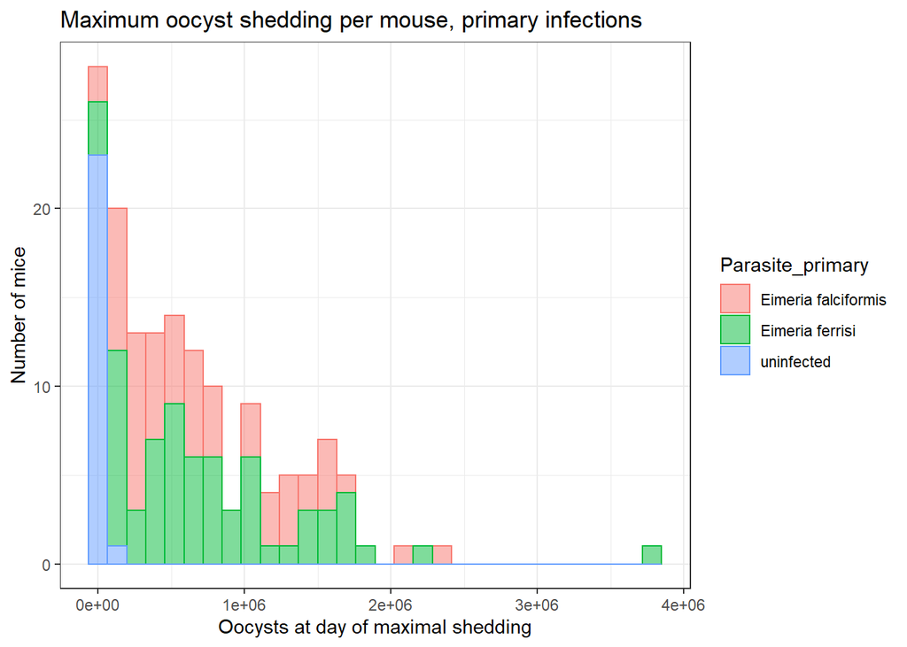

```r
CIMouse %>%
    filter(infection == "primary")  %>%
  ggplot(aes(max_OOC, color = Parasite_primary, fill = Parasite_primary)) +
  geom_histogram(bins = 30, alpha = 0.5) +
  labs(x = "Oocysts at day of maximal shedding", y = "Number of mice",
       title = "Maximum oocyst shedding per mouse, primary infections") +
    theme_bw()
```

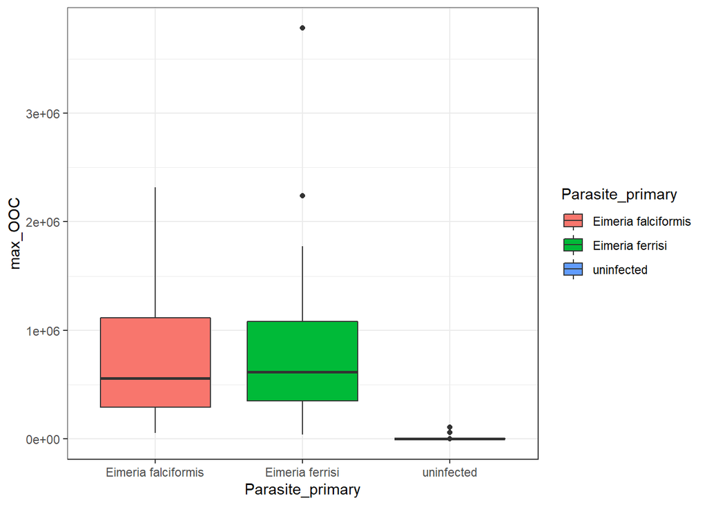

```r
CIMouse  %>%
    filter(infection == "primary")  %>%
  ggplot(aes(x = Parasite_primary, y = max_OOC, fill = Parasite_primary)) +
  geom_boxplot() +
    theme_bw()
```

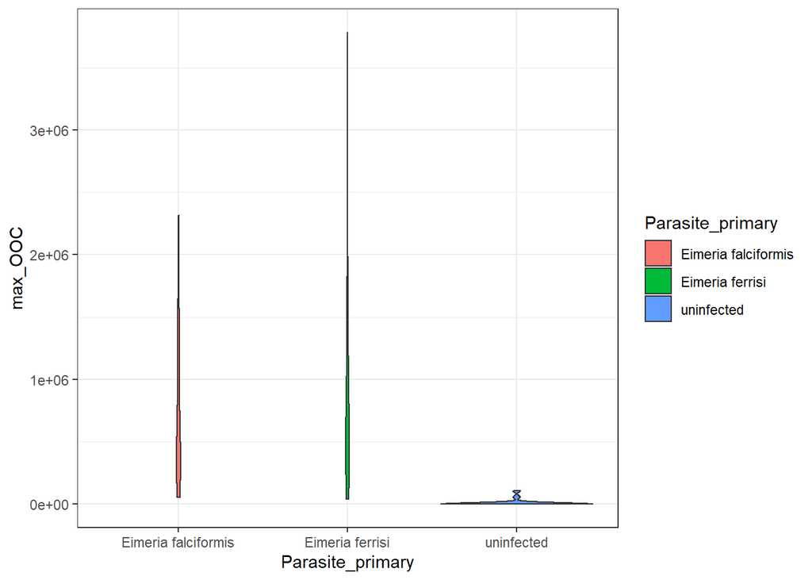

```r
CIMouse  %>%
    filter(infection == "primary")  %>%
  ggplot(aes(x = Parasite_primary, y = max_OOC, fill = Parasite_primary)) +
  geom_violin() +
    theme_bw()
```

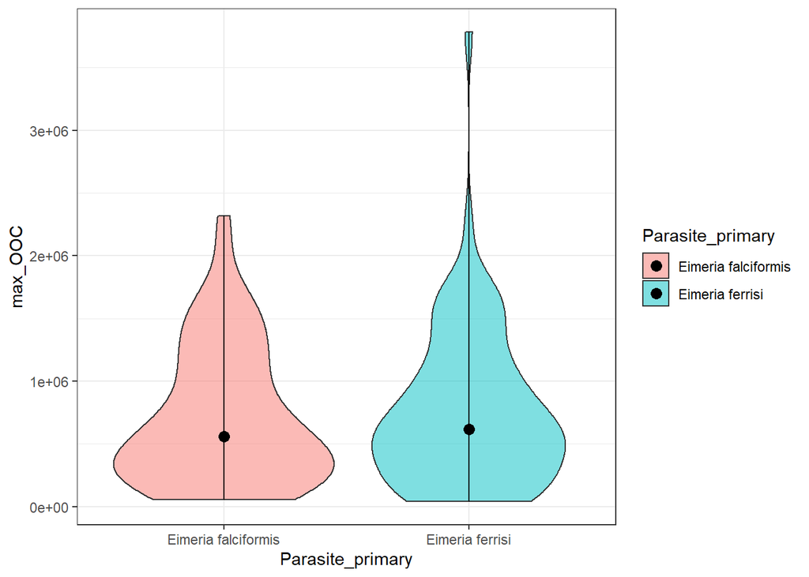

```r
CIMouse  %>%
    filter(infection == "primary", !Parasite_primary == "uninfected")  %>%
  ggplot(aes(x = Parasite_primary, y = max_OOC, fill = Parasite_primary)) +
  geom_violin(alpha = 0.5) +
    geom_line() +
     stat_summary(fun.y = "median", geom = "point", size = 3) +
    theme_bw()
```

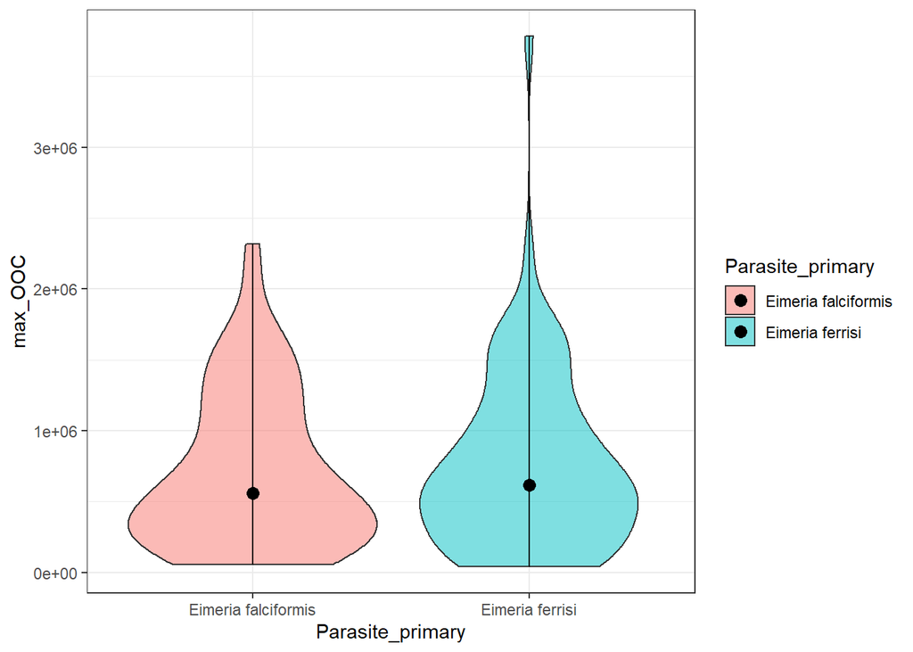

```r
CIMouse  %>%
    filter(infection == "primary", !Parasite_primary == "uninfected")  %>%
  ggplot(aes(x = Parasite_primary, y = max_OOC, fill = Parasite_primary)) +
  geom_violin(alpha = 0.5) +
    geom_line() +
     stat_summary(fun.y = "median", geom = "point", size = 3) +
    theme_bw()
```

2. And the challenge infections

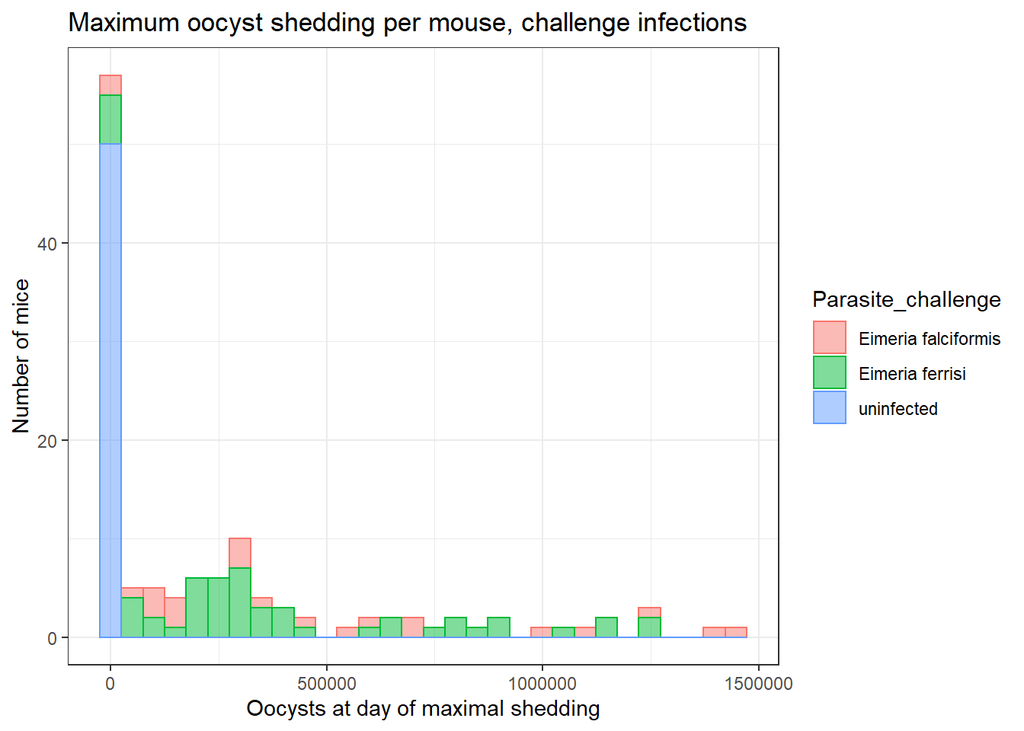

```r
CIMouse %>%
    filter(infection == "challenge")  %>%
  ggplot(aes(max_OOC, color = Parasite_challenge, fill = Parasite_challenge)) +
  geom_histogram(bins = 30, alpha = 0.5) +
  labs(x = "Oocysts at day of maximal shedding", y = "Number of mice",
       title = "Maximum oocyst shedding per mouse, challenge infections") +
    theme_bw()
```

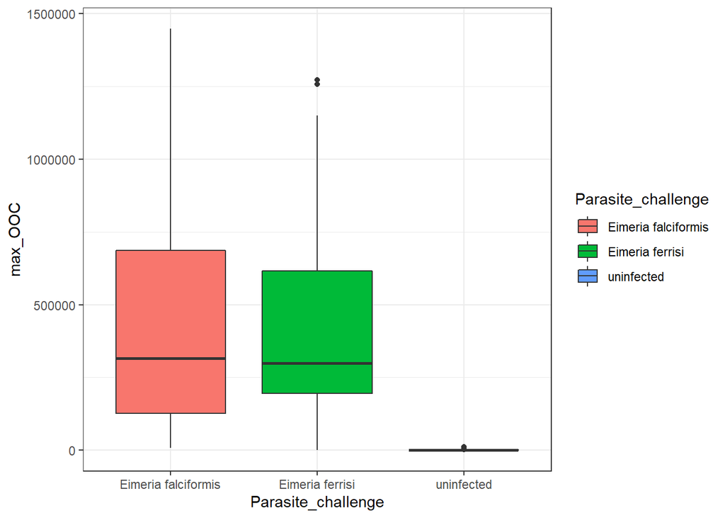

```r
CIMouse  %>%
    filter(infection == "challenge")  %>%
  ggplot(aes(x = Parasite_challenge, y = max_OOC, fill = Parasite_challenge)) +
  geom_boxplot() +
    theme_bw()
```

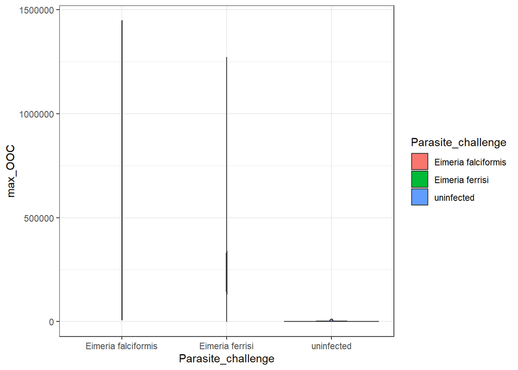

```r
CIMouse  %>%
    filter(infection == "challenge")  %>%
  ggplot(aes(x = Parasite_challenge, y = max_OOC, fill = Parasite_challenge)) +
  geom_violin() +
    theme_bw()
```

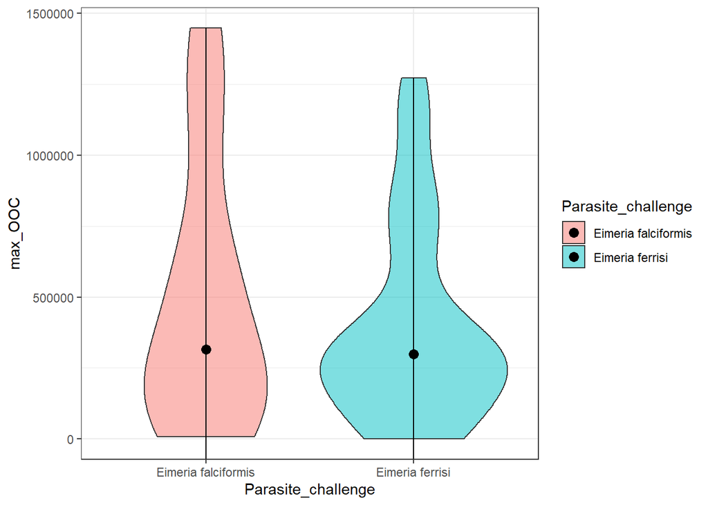

```r
CIMouse  %>%
    filter(infection == "challenge", !Parasite_challenge == "uninfected")  %>%
  ggplot(aes(x = Parasite_challenge, y = max_OOC, fill = Parasite_challenge)) +
  geom_violin(alpha = 0.5) +
    geom_line() +
     stat_summary(fun.y = "median", geom = "point", size = 3) +
    theme_bw()
```

#### maximum oocysts output for each mouse strain in each infection?

1. primary infections:

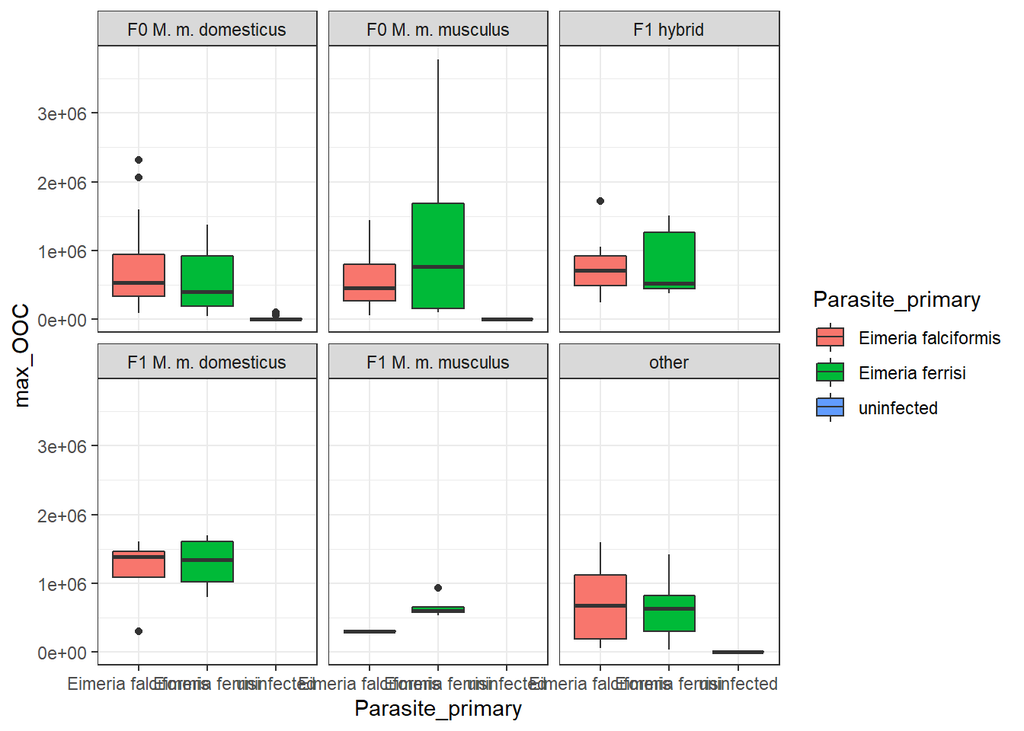

2. Challenge infections:

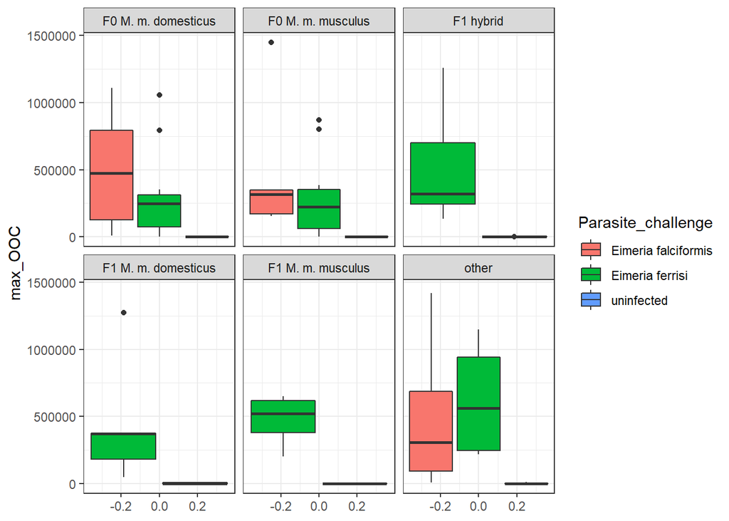

Effect of experiments on oocyst shedding?

1. primary infections:

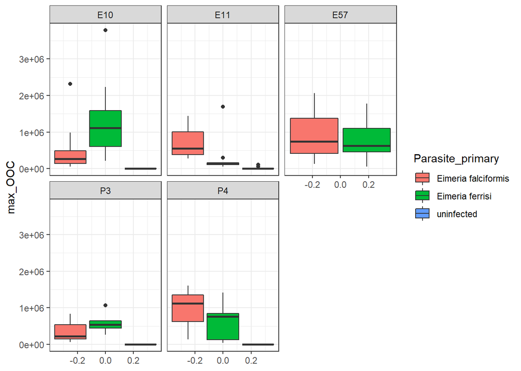

2. Challenge infections:

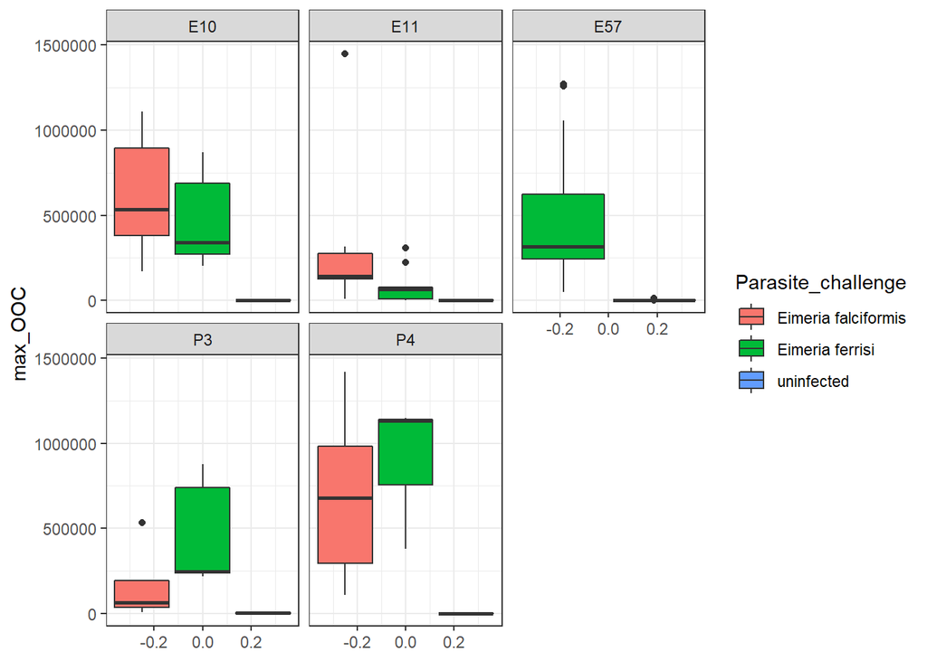

Patency in primary infections

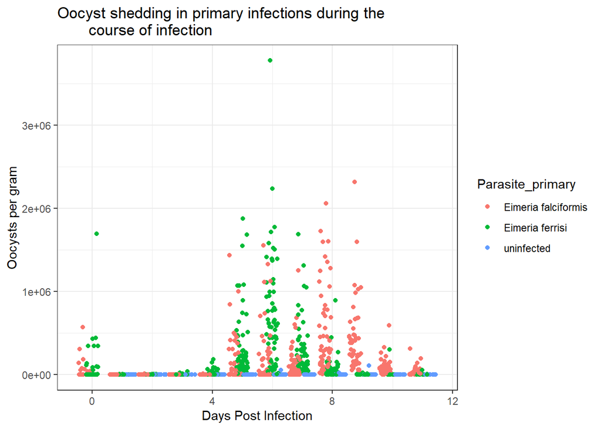

```r
CI %>%
  group_by("EH_ID") %>%
  filter(infection == "primary") %>%
  ggplot(aes(x = dpi, y = OOC, color = Parasite_primary)) +
  geom_point(position = position_jitterdodge()) +
  labs(x = "Days Post Infection", y = "Oocysts per gram",
       title = "Oocyst shedding in primary infections during the
       course of infection") +
    theme_bw()
```

Patency in primary infections - experiments

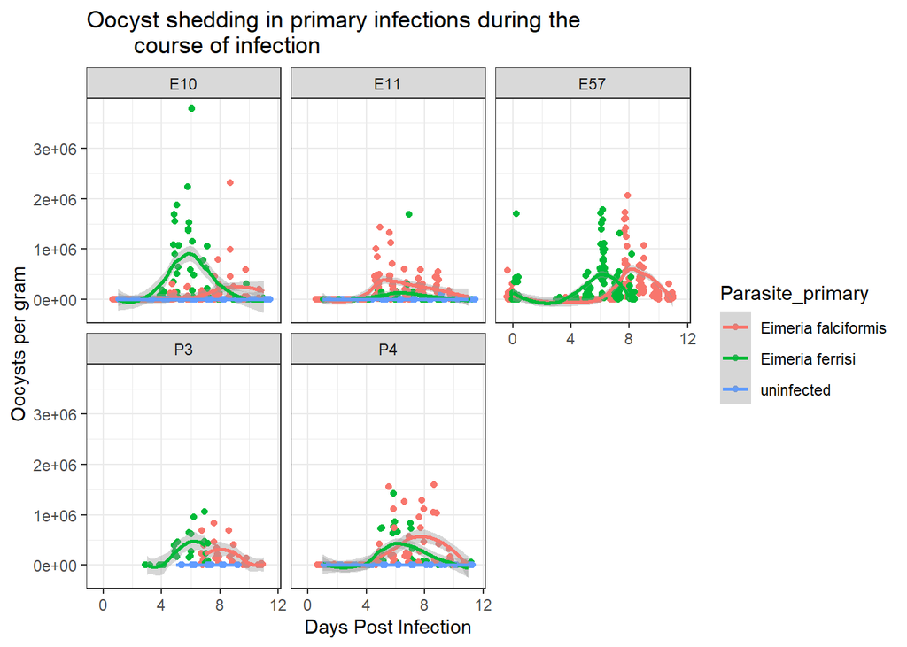

```r
CI %>%
  group_by("EH_ID") %>%
  filter(infection == "primary") %>%
  ggplot(aes(x = dpi, y = OOC, color = Parasite_primary)) +
  geom_point(position = position_jitterdodge()) +
  labs(x = "Days Post Infection", y = "Oocysts per gram",
       title = "Oocyst shedding in primary infections during the
       course of infection") +
    theme_bw() +
    stat_smooth() +
    facet_wrap(~ experiment)
```

Patency in primary infections - mouse strains

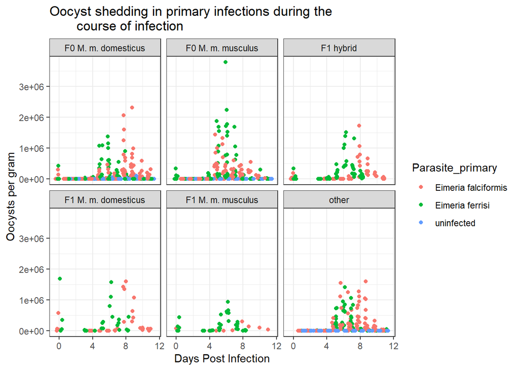

```r
CI %>%
  group_by("EH_ID") %>%
  filter(infection == "primary") %>%
  ggplot(aes(x = dpi, y = OOC, color = Parasite_primary)) +
  geom_point(position = position_jitterdodge()) +
  labs(x = "Days Post Infection", y = "Oocysts per gram",
       title = "Oocyst shedding in primary infections during the
       course of infection") +
    theme_bw() +
    facet_wrap(~ hybrid_status)
```

Patency in challenge infections - experiments

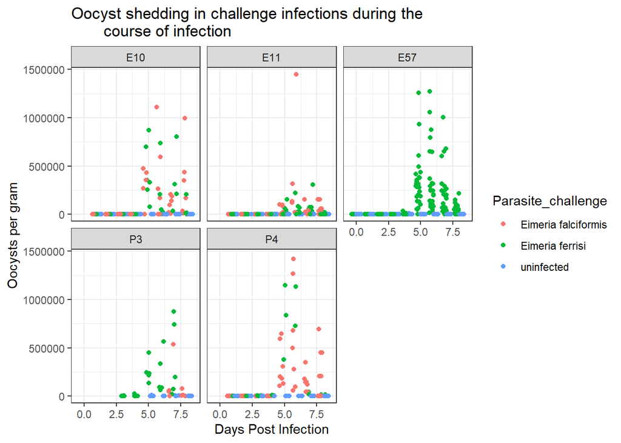

```r
CI %>%
  group_by("EH_ID") %>%
  filter(infection == "challenge") %>%
  ggplot(aes(x = dpi, y = OOC, color = Parasite_challenge)) +
  geom_point(position = position_jitterdodge()) +
  labs(x = "Days Post Infection", y = "Oocysts per gram",
       title = "Oocyst shedding in challenge infections during the
       course of infection") +
    theme_bw() +
    facet_wrap(~ experiment)
```

Patency in challenge infections - mouse strains

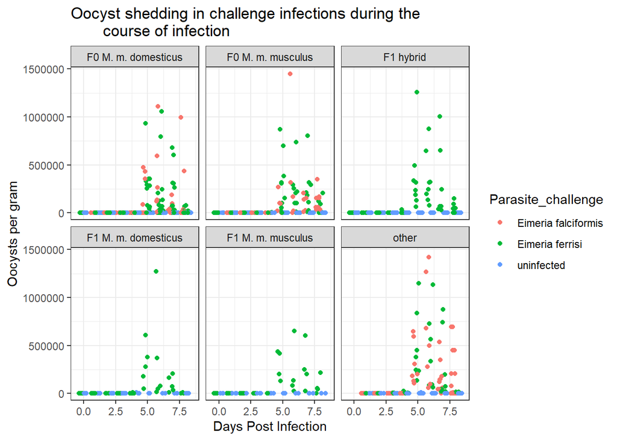

```r
CI %>%
  group_by("EH_ID") %>%
  filter(infection == "challenge") %>%
  ggplot(aes(x = dpi, y = OOC, color = Parasite_challenge)) +
  geom_point(position = position_jitterdodge()) +
  labs(x = "Days Post Infection", y = "Oocysts per gram",
       title = "Oocyst shedding in challenge infections during the
       course of infection") +
    theme_bw() +
    facet_wrap(~ hybrid_status)
```

#### What is the average max weight loss output for each mouse in the primary and challenge infections?

1. Visualizing the primary infections `

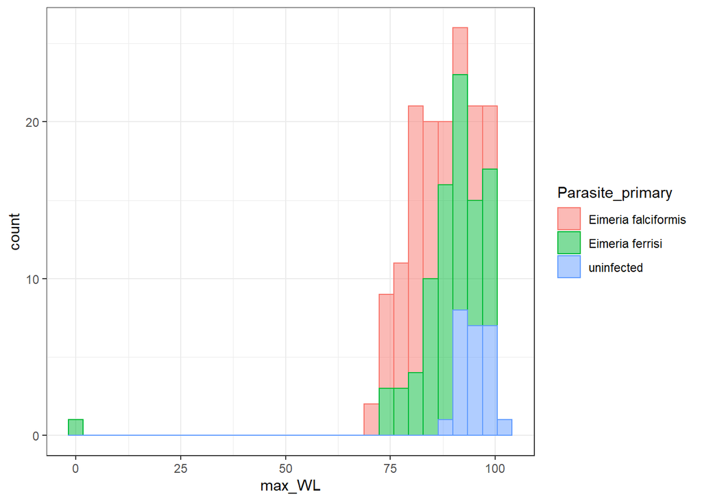

```r
CIMouse %>%
    dplyr::filter(infection == "primary") %>%
  ggplot(aes(max_WL, color = Parasite_primary, fill = Parasite_primary)) +
  geom_histogram(bins = 30, alpha = 0.5)  +
    theme_bw()
```

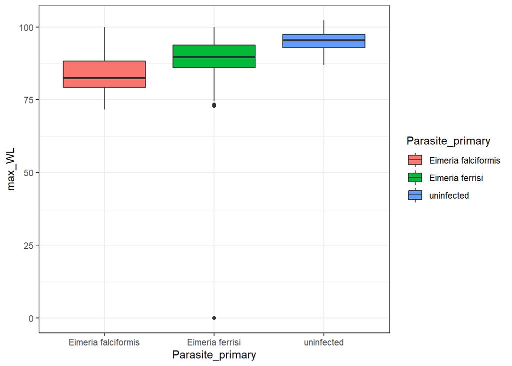

```r
CIMouse  %>%
    filter(infection == "primary")  %>%
  ggplot(aes(x = Parasite_primary, y = max_WL, fill = Parasite_primary)) +
  geom_boxplot() +
    theme_bw()
```

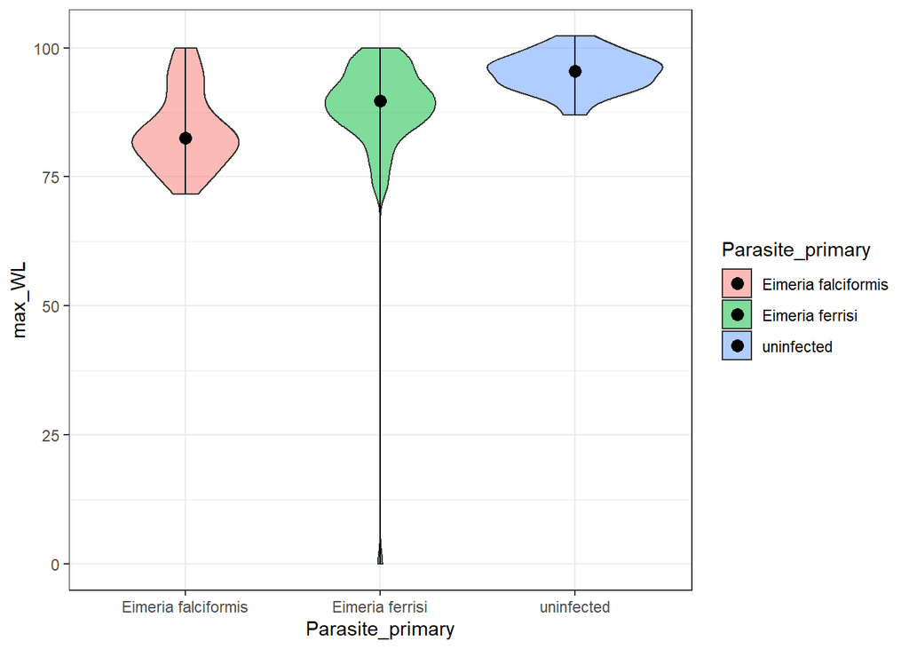

```r
CIMouse  %>%
    filter(infection == "primary")  %>%
  ggplot(aes(x = Parasite_primary, y = max_WL, fill = Parasite_primary)) +
  geom_violin(alpha = 0.5) +
    geom_line() +
     stat_summary(fun.y = "median", geom = "point", size = 3) +
    theme_bw()
```

2. And the challenge infections

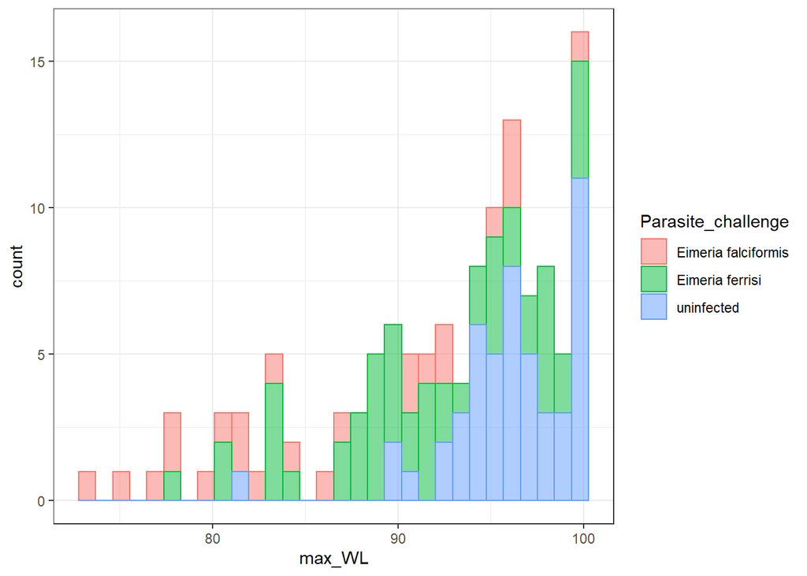

```r
CIMouse %>%
    filter(infection == "challenge")  %>%
  ggplot(aes(max_WL, color = Parasite_challenge, fill = Parasite_challenge)) +
  geom_histogram(bins = 30, alpha = 0.5) +
    theme_bw()
```

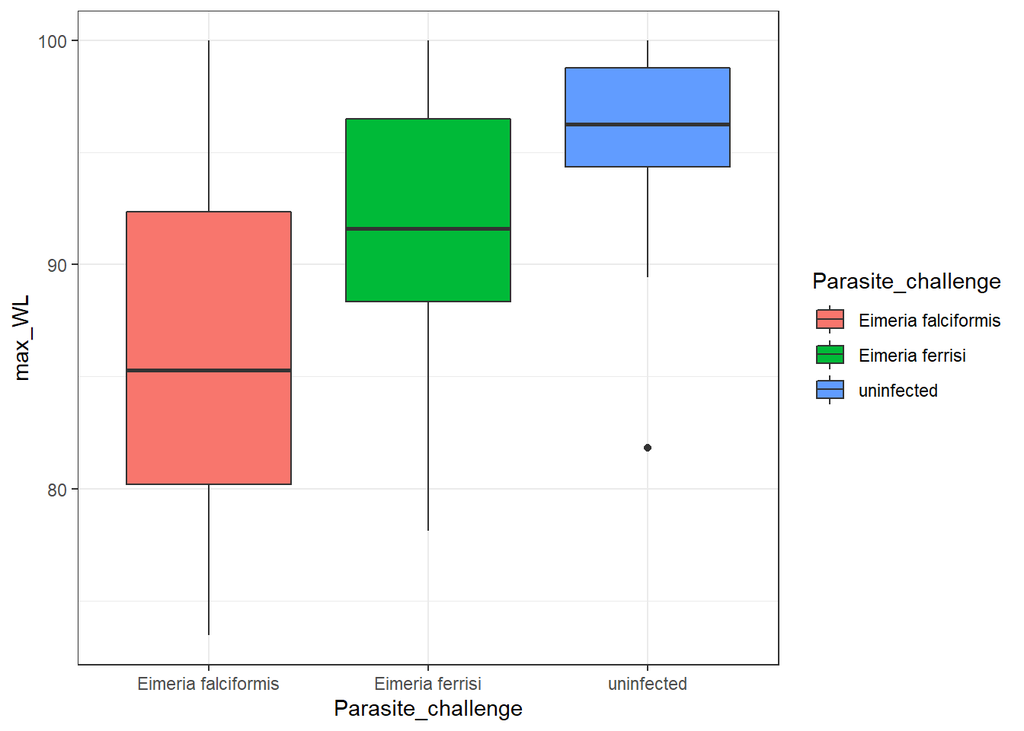

```r
CIMouse  %>%
    filter(infection == "challenge")  %>%
  ggplot(aes(x = Parasite_challenge, y = max_WL, fill = Parasite_challenge)) +
  geom_boxplot() +
    theme_bw()
```

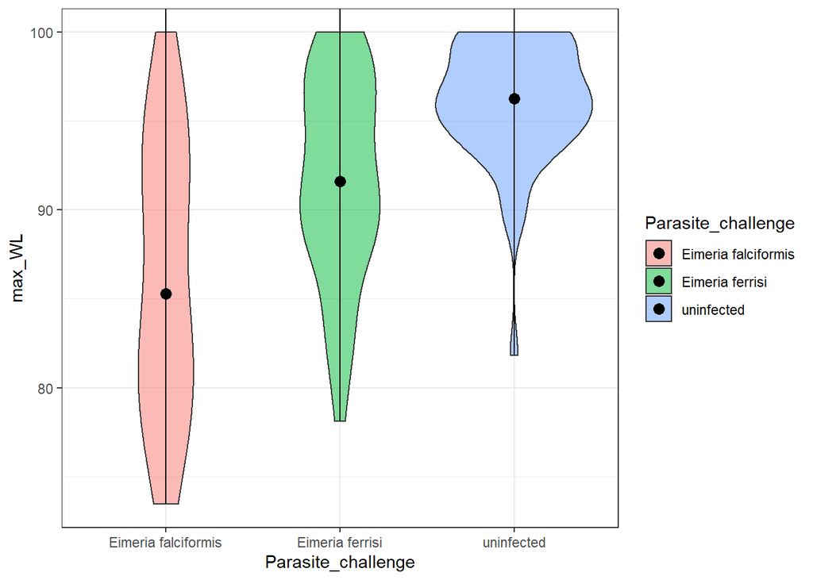

```r
CIMouse  %>%
    filter(infection == "challenge")  %>%
  ggplot(aes(x = Parasite_challenge, y = max_WL, fill = Parasite_challenge)) +
  geom_violin(alpha = 0.5) +
    geom_line() +
     stat_summary(fun.y = "median", geom = "point", size = 3) +
    theme_bw()
```

#### maximum weight loss output for each mouse strain in each infection?

1. primary infections:

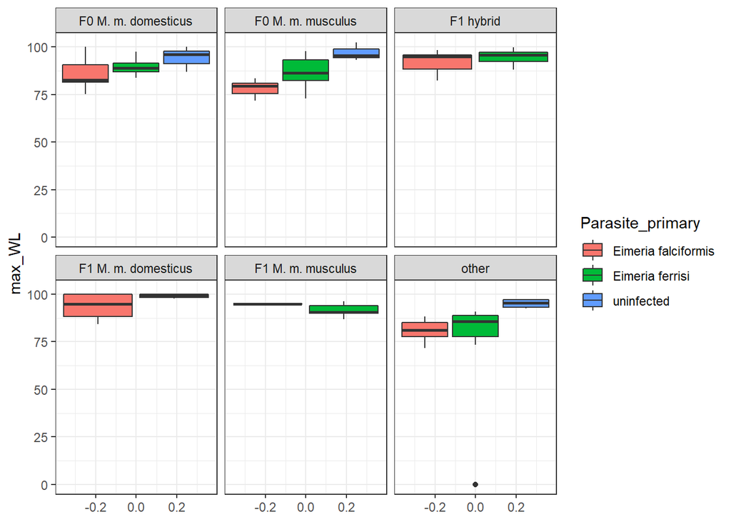

2. Challenge infections:

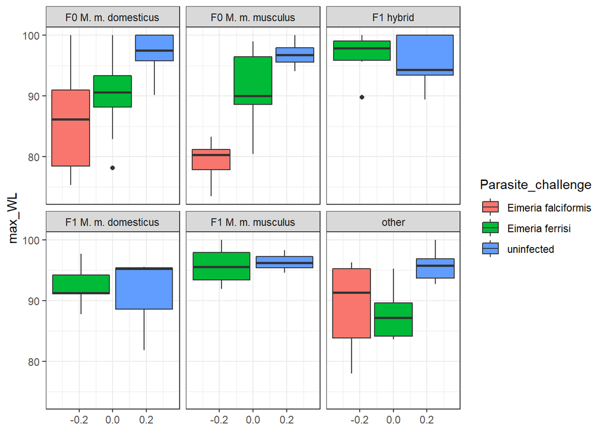

Effect of experiments on weight loss?

1. primary infections:

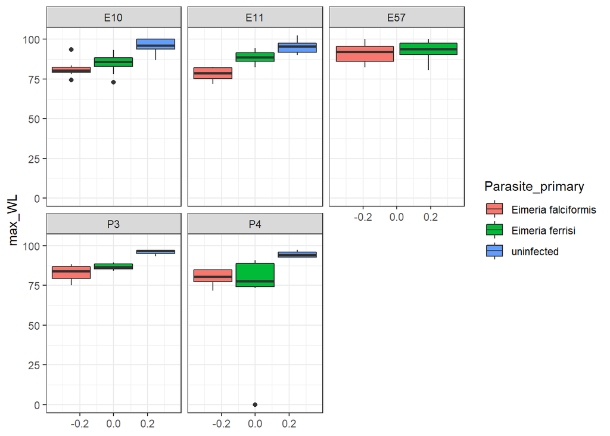

   Weight changes during the course of infection
2. Primary

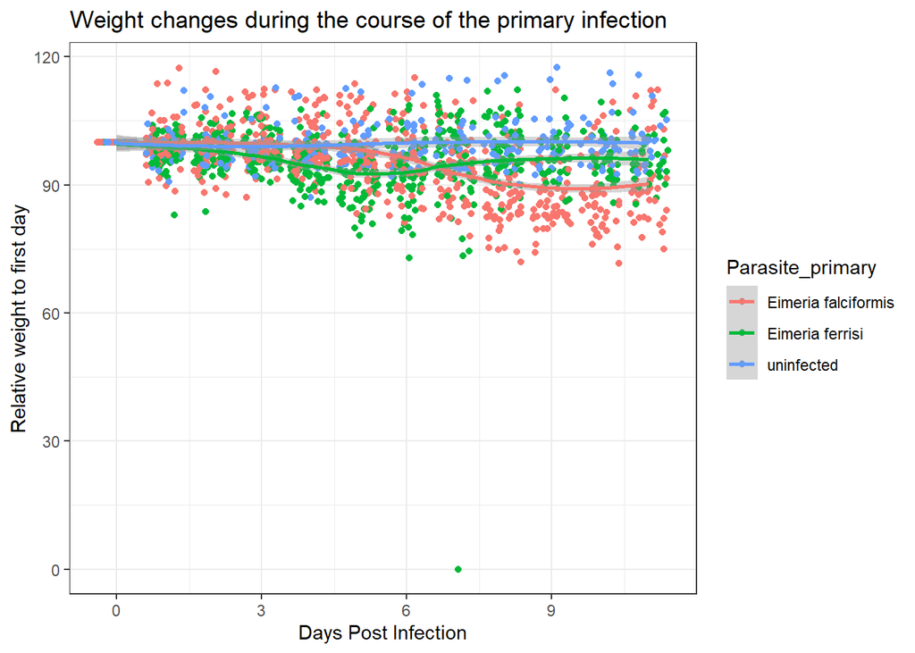

```r
CI %>%
    filter(infection == "primary") %>%
    drop_na(weight_dpi0, relative_weight) %>%
    group_by("EH_ID") %>%
    ggplot(aes(x = dpi, y = relative_weight, color = Parasite_primary)) +
    geom_jitter() +
    stat_smooth() +
    labs(x = "Days Post Infection", y = "Relative weight to first day",
         title = "Weight changes during the course of the primary infection") +
    theme_bw()
```

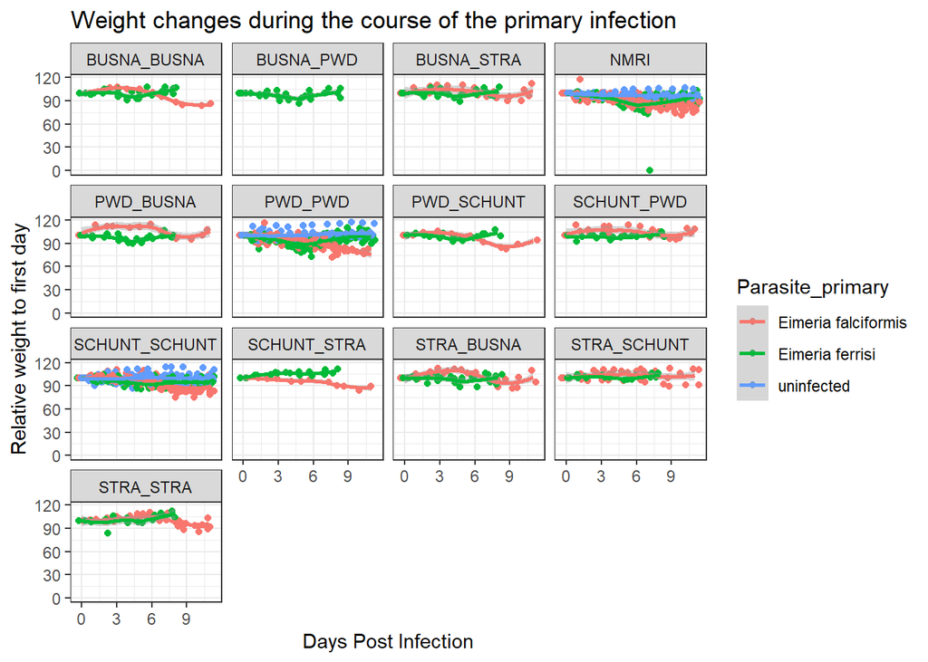

```r
CI %>%
    filter(infection == "primary") %>%
    drop_na(weight_dpi0, relative_weight) %>%
    group_by("EH_ID") %>%
    ggplot(aes(x = dpi, y = relative_weight, color = Parasite_primary)) +
    geom_jitter() +
    stat_smooth() +
    facet_wrap(~ mouse_strain) +
    labs(x = "Days Post Infection", y = "Relative weight to first day",
         title = "Weight changes during the course of the primary infection") +
    theme_bw()
```

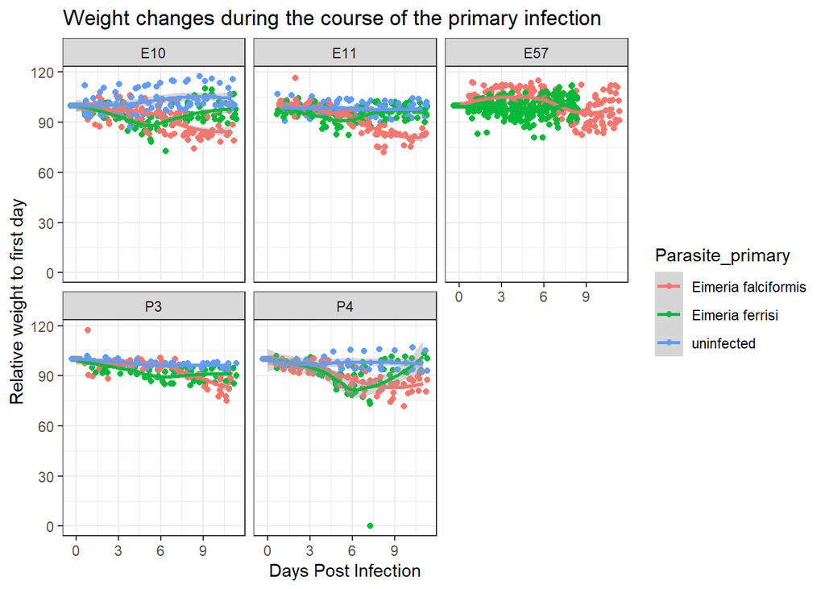

```r
CI %>%
    filter(infection == "primary") %>%
    drop_na(weight_dpi0, relative_weight) %>%
    group_by("EH_ID") %>%
    ggplot(aes(x = dpi, y = relative_weight, color = Parasite_primary)) +
    geom_jitter() +
    stat_smooth() +
    facet_wrap(~ experiment) +
    labs(x = "Days Post Infection", y = "Relative weight to first day",
         title = "Weight changes during the course of the primary infection") +
    theme_bw()
```

Weight changes during the course of infection 1. challenge

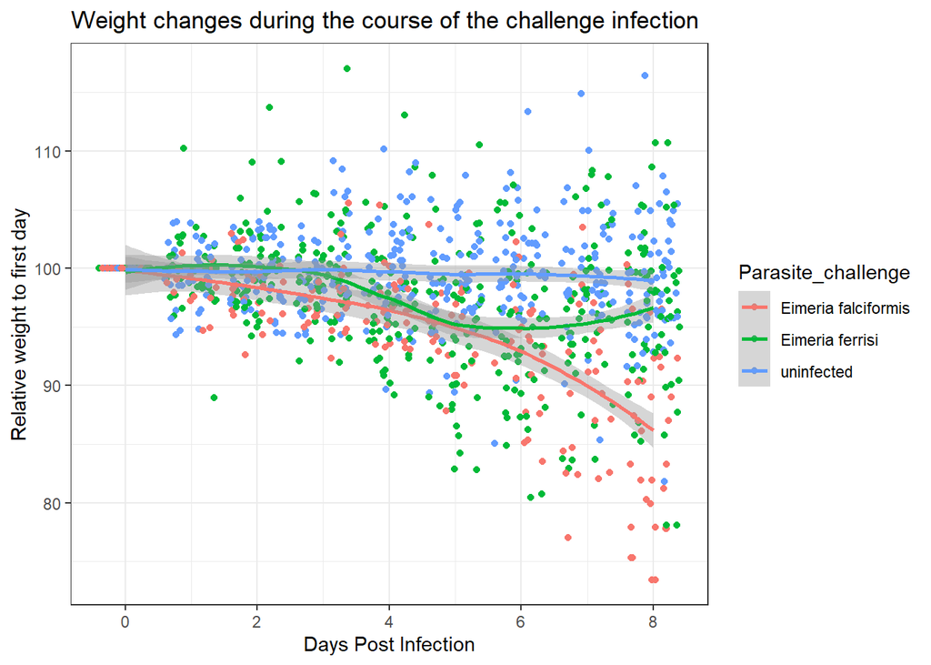

```r
CI %>%
    filter(infection == "challenge") %>%
    drop_na(weight_dpi0, relative_weight) %>%
    group_by("EH_ID") %>%
    ggplot(aes(x = dpi, y = relative_weight, color = Parasite_challenge)) +
    geom_jitter() +
    stat_smooth() +
    labs(x = "Days Post Infection", y = "Relative weight to first day",
         title = "Weight changes during the course of the challenge infection") +
    theme_bw()
```